# Draft Ft Keogh stocking for patch-burning research

DAM

Version 2022-06-14

# Baseline productivity

This section just reviews forage productivity and recommended stocking rates for pastures along the southern boundary of Fort Keogh.

Area (acreage) of candidate patch-burning pastures.

| pasture | Acres |
| --- | --- |
| Upper Lignite Creek | 12416 |
| Upper Coal Creek | 10267 |
| 3 Pasture | 7653 |
| 2a North | 5468 |
| Moon Creek | 4662 |
| 2a South | 4366 |
| N 4 | 2485 |
| Sandridge North | 1463 |
| S 4 | 1463 |
| Sandridge South | 1207 |

Productivity data from SSURGO Rangeland Productivity:

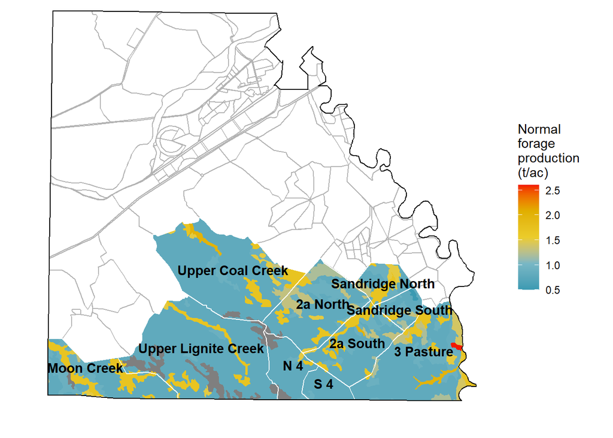

Stocking rate calculations follow the [MT NRCS stocking guide](https://www.nrcs.usda.gov/Internet/FSE_DOCUMENTS/nrcs144p2_054048.pdf).

Then multiplied by an efficiency factor, 0.25.

Available AUMs by candidate patch-burn pasture under three precipitation scenarios.

| pasture | high | low | norm |
| --- | --- | --- | --- |
| Upper Lignite Creek | 3418 | 1847 | 2641 |
| Upper Coal Creek | 3311 | 1742 | 2523 |
| 3 Pasture | 2790 | 1437 | 2094 |
| 2a North | 2098 | 1084 | 1575 |
| Moon Creek | 1858 | 931.9 | 1396 |
| 2a South | 1642 | 855.4 | 1246 |
| N 4 | 711.7 | 388.3 | 549 |
| Sandridge North | 625.5 | 315 | 472.1 |
| Sandridge South | 488.8 | 245.7 | 362.7 |
| S 4 | 450.2 | 247.4 | 348.6 |

So if a grazing season is to last 5 mo, the following number of cows would be assigned to each pasture: *First, script to calculate stocking rate*

```r
pbg_prod %>%
    mutate(acres = as.numeric(st_area(.) * 0.0002471054), # sq. m. to acres
         across(c(low, norm, high), ~ . * acres) ) %>%    # per-acre production x acreage
  pivot_longer(names_to = "scenario",
               values_to = "t_ac",
               cols = c('low', 'norm', 'high')) %>%
  filter(!is.na(t_ac)) %>%
  group_by(scenario, pasture) %>%
  summarize(productivity = sum(t_ac),           # total productivity for each unit
            .groups = 'drop') %>%
  mutate(pairs = ((productivity*eff)/915)/5,    # stocking for 5 mo; eff = efficiency factor
         pairs = round(pairs, 0)) %>%
  as_tibble() %>%
  select(-geometry, -productivity) %>%
  pivot_wider(names_from = scenario,
              values_from = pairs) %>%
  arrange(desc(norm)) %>%
  pander::pander("Number of cow-calf pairs to stock for 5 mo at 50% forage consumption under three precipitation scenarios.")
```

Number of cow-calf pairs to stock for 5 mo at 50% forage consumption under three precipitation scenarios.

| pasture | high | low | norm |
| --- | --- | --- | --- |
| Upper Lignite Creek | 684 | 369 | 528 |
| Upper Coal Creek | 662 | 348 | 505 |
| 3 Pasture | 558 | 287 | 419 |
| 2a North | 420 | 217 | 315 |
| Moon Creek | 372 | 186 | 279 |
| 2a South | 328 | 171 | 249 |
| N 4 | 142 | 78 | 110 |
| Sandridge North | 125 | 63 | 94 |
| Sandridge South | 98 | 49 | 73 |
| S 4 | 90 | 49 | 70 |

# Potential study designs

The proposed patch-burning study will compare two different fire regimes:

- *4-yr fire return interval* in which 1/4 of each pasture is burned every year.
- *8-y fire return interval* in which 1/4 of each pasture is burned every other year.

Grazing within each is discussed below.

Given the variability of pasture sizes in the candidate set and non-study needs for grazing availability, the candidate patch-burning pastures are classified into two categories:

- *Study pastures* in which the timing, duration, and number of grazing animals are regulated
- *Adaptive management pastures* in which patches are burned according to a fire management plan and grazing worked into as necessary

## Study pastures

8 smaller to mid-size pastures selected for research in what could formally be called a patch-burn grazing study, in that fire and grazing regimes will both be experimentally manipulated.

In addition to the two fire regimes (4-yr and 8-yr fire return intervals), two grazing regimes will be applied:

- *Annual grazing* in which each pasture will be stocked in every year of the study
- *Biennial grazing* in which each pasture will only be grazed every other year

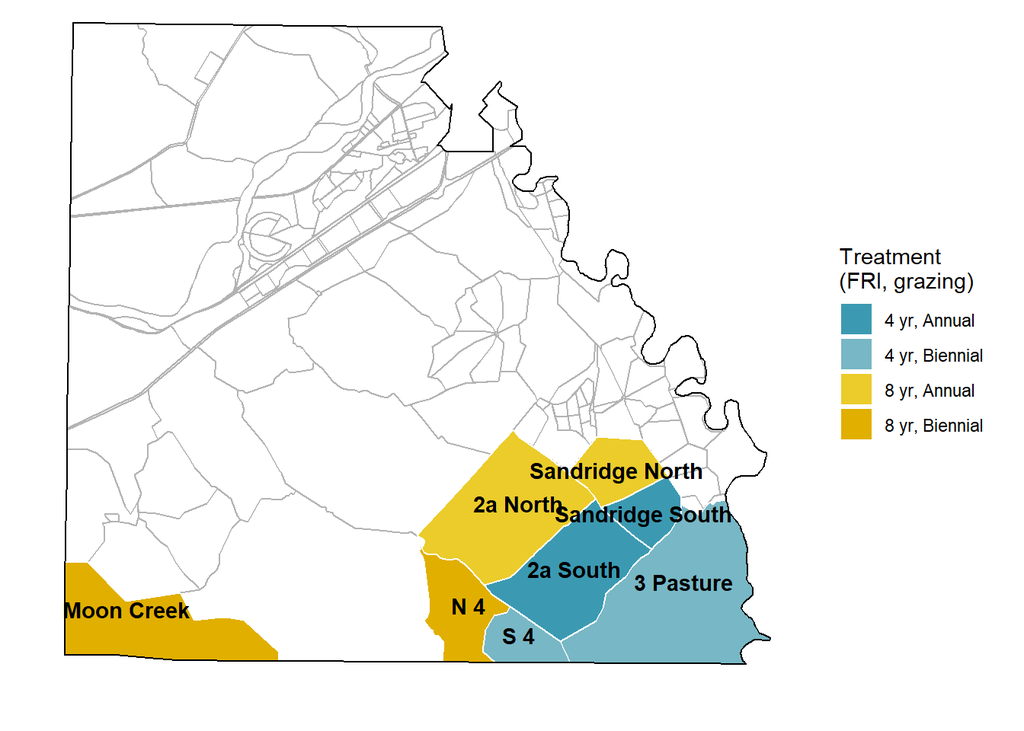

### Ecological sites

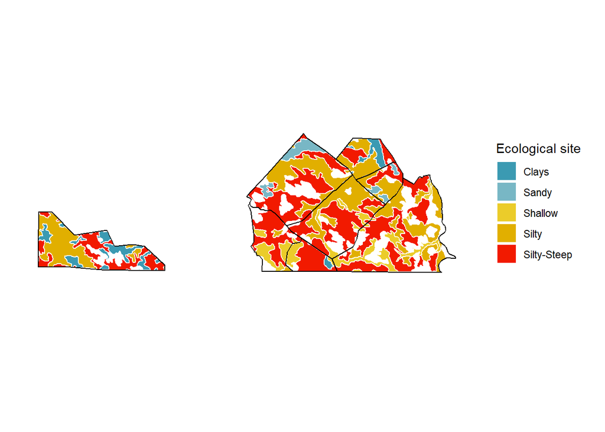

| pasture | Silty-Steep | Silty | Sandy | Shallow | Clays |
| --- | --- | --- | --- | --- | --- |
| 2a North | 2734 | 1349 | 624.4 | NA | NA |
| 2a South | 2353 | 1241 | NA | 362.2 | NA |
| 3 Pasture | 3522 | 1508 | NA | 1230 | NA |
| Moon Creek | 1796 | 1692 | NA | NA | 792.9 |
| N 4 | 1437 | 106.3 | NA | 782.3 | NA |
| S 4 | 994.1 | NA | NA | 358.7 | 60.17 |
| Sandridge North | 539.9 | 677.7 | NA | NA | 215.5 |
| Sandridge South | 437.3 | 522.2 | 193.8 | NA | NA |

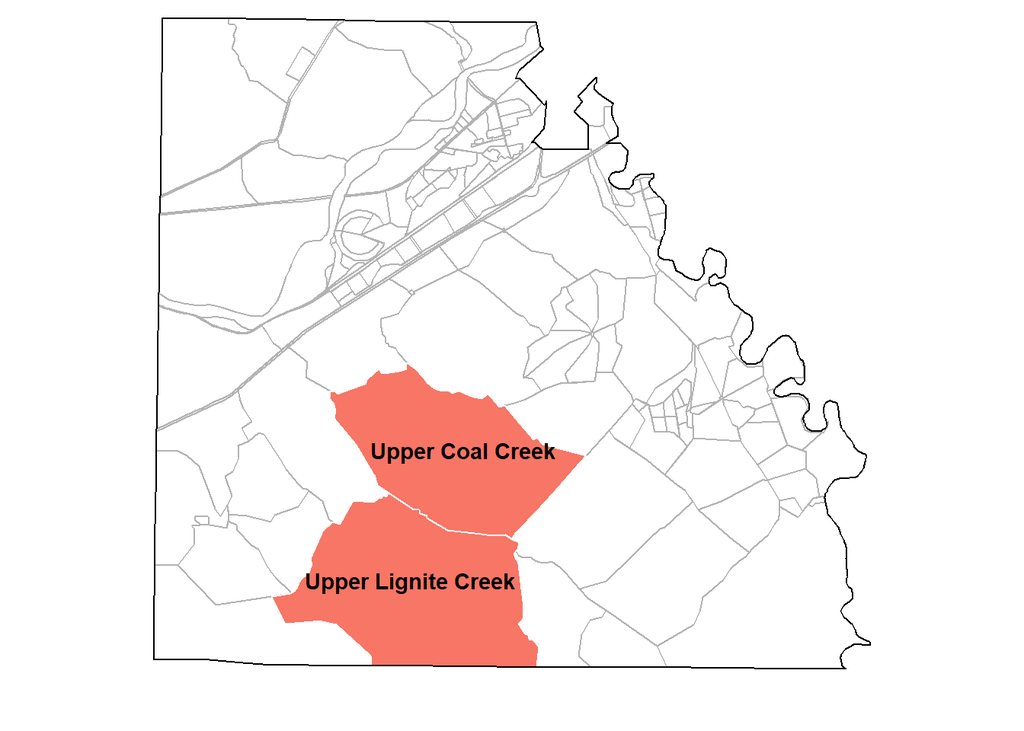